# R Session 5

Kalie and Rebecca

2023-04-11

## Excersise 1

1. Create a function called circle that takes radius, r, as a single argument. The function should output both area and circumference. Try 1 and 2 for the value of r.

```r
circle <- function(r){
    circumference = 2*pi*r
    area = pi*r^2
    output <- list(circumference, area)
    return(output)
}
print(circle(1))
```

```
## [[1]]
## [1] 6.283185
##
## [[2]]
## [1] 3.141593
```

```r
print(circle(2))
```

```
## [[1]]
## [1] 12.56637
##
## [[2]]
## [1] 12.56637
```

2. Create a function that converts Fahrenheit to Celsius. Feel free to look up online for the equation. Try 32F and 212F.

```r
toCelsius = function(farenheit) {
f = (farenheit - 30)*(0.5);
return(f);
}
toCelsius(32)
```

```
## [1] 1
```

```r
toCelsius(212)
```

```
## [1] 91
```

3. Create a function that takes three arguments of your choice. At least one of the arguments should have a default value. Be creative.

```r
#Converting kilometer to mile
toMiles = function(kilometer){
  k = kilometer/1.609;
  return(k);
}
toMiles(47.2)
```

```
## [1] 29.33499
```

```r
toMiles(5)
```

```
## [1] 3.10752
```

```r
toMiles(10.2)
```

```
## [1] 6.339341
```

## Excersise 2

1. How can we make the estimation more accurate?

You can make the estimation of pi more accurate to the expected value of 3.14 by increasing the number of trials.

2. Try your answer to see if it improves the estimation.

After applying my hypothesis that more trials would bring the estimation of pi closer to the expected value of 3.14, was correct. The estimation of pi went from 3.1786 to 3.1576.

```r
set.seed(123)
n <- 10000
pts <- tibble(x = runif(n, -1, 1),
              y = runif(n, -1, 1))
```

```r
pts <- pts %>% mutate(dist = sqrt(x^2 + y^2))
pts
```

```
## # A tibble: 10,000 × 3
##          x      y  dist
##      <dbl>  <dbl> <dbl>
##  1 -0.425  -0.379 0.569
##  2  0.577  -0.351 0.675
##  3 -0.182   0.741 0.763
##  4  0.766  -0.343 0.839
##  5  0.881  -0.749 1.16
##  6 -0.909  -0.288 0.953
##  7  0.0562  0.861 0.863
##  8  0.785   0.750 1.09
##  9  0.103   0.640 0.649
## 10 -0.0868 -0.956 0.960
## # ℹ 9,990 more rows
```

```r
pts <- pts %>% mutate(in_circle = dist < 1)
pts
```

```
## # A tibble: 10,000 × 4
##          x      y  dist in_circle
##      <dbl>  <dbl> <dbl> <lgl>
##  1 -0.425  -0.379 0.569 TRUE
##  2  0.577  -0.351 0.675 TRUE
##  3 -0.182   0.741 0.763 TRUE
##  4  0.766  -0.343 0.839 TRUE
##  5  0.881  -0.749 1.16  FALSE
##  6 -0.909  -0.288 0.953 TRUE
##  7  0.0562  0.861 0.863 TRUE
##  8  0.785   0.750 1.09  FALSE
##  9  0.103   0.640 0.649 TRUE
## 10 -0.0868 -0.956 0.960 TRUE
## # ℹ 9,990 more rows
```

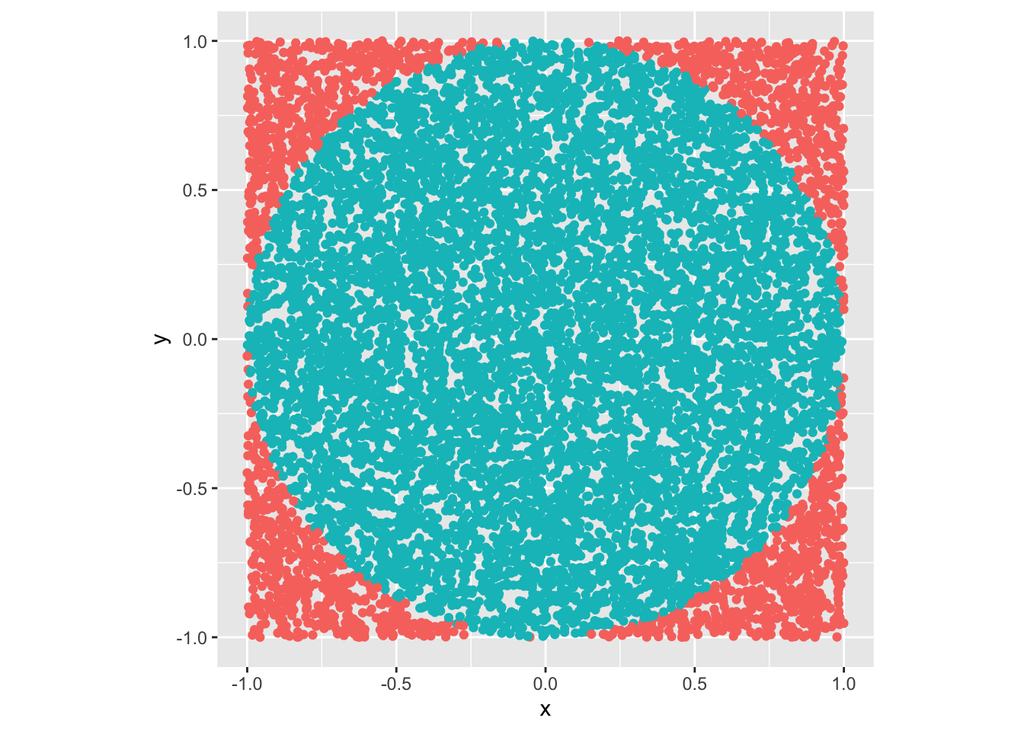

```r
pts %>% ggplot(aes(x = x, y = y, color = in_circle)) +
  geom_point() +
  theme(legend.position = "none") +
  coord_fixed()
```

```r
4 * mean(pts$in_circle)
```

```
## [1] 3.1576
```

## Excersise 3

1. Make a function that has three arguements: n, lb, and ub. The function should generate n random numbers between lb and ub then outputs the average of these n random numbers. Make 10, 0, 1 as the default value of n, lb, and ub, respectively.

```r
output = function(n, lb, ub){
  this = generate <- runif(n, lb, ub);
  return(this)
}
print(mean(output(10, 0, 1)))
```

```
## [1] 0.4781225
```

## Excersise 4

1. Theoretically, what would be the average of random numbers between 0 and 1.

The average of random numbers between 0 and 1 would be 0.5

2. Instead of repeating the random process twice, repeat 1,000 times. Please do not output 1,000 values. Does this match with your answer from the previous question?

```r
output = function(n, lb, ub){
  this = generate <- runif(n, lb, ub);
  return(this)
}
print(mean(output(1000, 0, 1)))
```

```
## [1] 0.496509
```

3. Instead of generating random numbers between 0 and 1, imagine doing this between 0 and 100. What would be the theoretical average?

The theoretical average of generating random numbers between 0 and 100 would be 50.

4. Modify the above function to obtain an average of random numbers between 0 and 100.

```r
output = function(n, lb, ub){
  this = generate <- runif(n, lb, ub);
  return(this)
}
print(mean(output(10, 1, 100)))
```

```
## [1] 54.22422
```